# The Application of Logistic Regression to Examine the Predictors of Car Crashes Caused by Alcohol

CPLN 671 / MUSA 5000: Statistics and Data Mining

Sara Cerami, Gautami Kasat, Tegan Lochner

November 28, 2026

# 1 Introduction

Drunk driving is one of the most preventable causes of death on American roads. According to the US Department of Transportation, almost 30 people a day, or roughly one person every 51 minutes, die in motor vehicle crashes that involve an alcohol-impaired driver, and many more are injured. The National Highway Traffic Safety Administration estimates that alcohol-related crashes cost the country more than $59 billion each year. For a city, knowing how often these crashes happen is only part of the picture. Knowing what they look like, and where they occur, is what allows enforcement, education campaigns and street design changes to be aimed where they will do the most good. This report focuses on Philadelphia, using all 53,260 crashes recorded by the Pennsylvania Department of Transportation between 2008 and 2012 and published on OpenDataPhilly. Each crash was spatially joined to the 2000 Census block group in which it occurred. After removing the 9,896 crashes that took place in non-residential block groups, the analysis covers the 43,364 crashes that occurred in the city’s residential neighborhoods.

We examine nine possible predictors of whether a crash involved a drinking driver. Most describe the crash itself. Alcohol slows reaction time and weakens judgment, so we expect speeding and aggressive driving to be more common in drunk-driving crashes, and we expect those crashes to be more severe, more often ending in a fatality, a major injury or an overturned vehicle. Cell phone use is a different kind of distraction, and we see no clear reason why it should go hand in hand with drinking. Two predictors capture driver age. Crashes involving 16- or 17-year-olds should be less likely to involve alcohol, since these drivers are well below the legal drinking age and Pennsylvania’s junior license limits late-night driving. Crashes involving drivers aged 65 or older should also be less likely to involve alcohol, since older adults tend to drive less at night and drink less heavily. The last two predictors describe the neighborhood where the crash happened: the share of adults with at least a bachelor’s degree and the median household income. Their direction is harder to predict. Wealthier, more educated block groups may have more bars and restaurants and residents with more money to spend on nights out, but they may also see less of the late-night traffic in which drunk-driving crashes tend to occur. To test these relationships, we first explore how each predictor relates to drunk driving and then use R to run a logistic regression of the binary outcome, DRINKING_D, on all nine predictors.

# 2 Methods

## 2.1 Why not OLS?

Ordinary least squares (OLS) regression is designed for a continuous dependent variable. When the dependent variable is binary (here, DRINKING_D, which equals 1 if a crash involved a drunk driver and 0 otherwise), OLS, which in this setting is called the *linear probability model*, runs into several problems:

1. **Predicted values are not valid probabilities.** OLS fits a straight line, which is unbounded. For some combinations of predictor values the fitted value can be less than 0 or greater than 1, which makes no sense for the probability that an event occurs.
2. **The relationship is not linear.** OLS assumes that a one-unit change in a predictor changes the dependent variable by the same amount everywhere. For a probability, which is bounded between 0 and 1, the effect of a predictor must get smaller as the probability approaches 0 or 1, so the true relationship between the predictors and the probability of the event is S-shaped, not a straight line.
3. **The errors cannot be normally distributed.** For any given set of predictor values the dependent variable takes only two values (0 or 1), so the error term can also take only two values. A two-valued variable cannot follow a normal distribution, which undermines the usual t-tests and confidence intervals from OLS.
4. **The error variance is not constant (heteroskedasticity).** The variance of a binary variable is $p(1-p)$, which depends on its mean, so the variance of the errors changes with the values of the predictors. This violates the OLS assumption of homoscedasticity and makes the OLS standard errors unreliable.

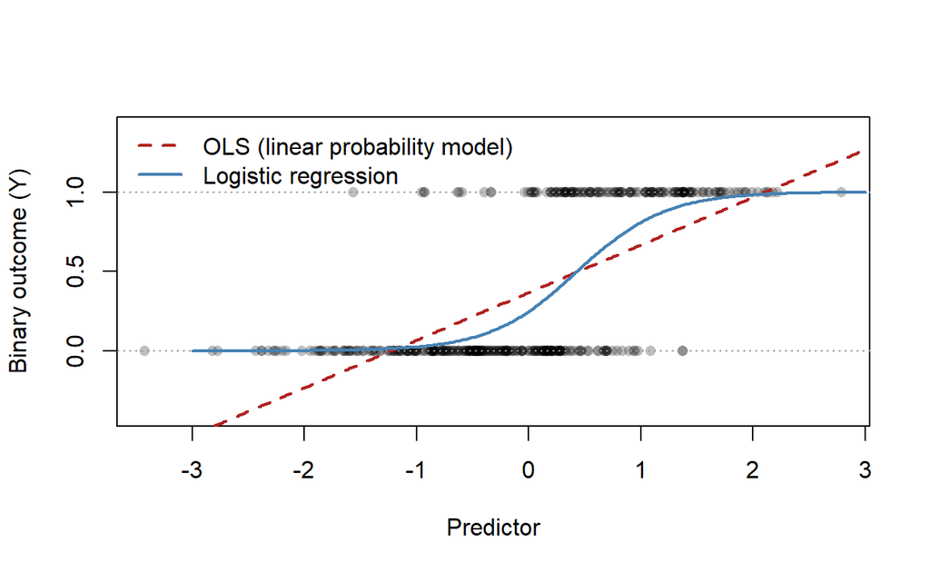

Illustration with simulated data: an OLS line fitted to a binary outcome (dashed) leaves the 0 to 1 range, while the logistic curve (solid) stays within it.

## 2.2 How logistic regression works around these issues

Logistic regression avoids these problems by modeling the *probability* of the event through a transformation that is S-shaped and bounded between 0 and 1, rather than modeling the binary outcome directly. Because the model is estimated by maximum likelihood using the binomial distribution (rather than by least squares), it does not require normally distributed, constant-variance errors. To describe the model we first need the concept of odds.

### 2.2.1 Odds and odds ratios

The **odds** of an event are the probability that it occurs divided by the probability that it does not:

$$\text{odds} = \frac{p}{1-p}$$

For example, if the probability that a crash involves a drunk driver is $p = 0.20$, the odds are $0.20/0.80 = 0.25$, or 1 to 4. Odds equal 1 when the event is as likely as not ($p = 0.5$), are greater than 1 when the event is more likely than not, and are less than 1 when it is less likely than not. Unlike probabilities, odds have no upper limit, and they can be converted back to probabilities with $p = \text{odds}/(1+\text{odds})$.

An **odds ratio** (OR) is the ratio of the odds of the event under two different conditions, for example the odds of a drunk driver in crashes involving speeding divided by the odds in crashes not involving speeding. It is interpreted as follows:

- **OR = 1:** the odds are the same in both conditions, so there is no association.
- **OR > 1:** the odds of the event are higher under the first condition. The percent increase in the odds is $(OR - 1) \times 100$ (for example, OR = 1.5 means 50% higher odds).
- **OR < 1:** the odds of the event are lower under the first condition. The percent decrease in the odds is $(1 - OR) \times 100$ (for example, OR = 0.6 means 40% lower odds).

In a logistic regression, the odds ratio for a predictor is the multiplicative change in the odds that $Y = 1$ for a one-unit increase in that predictor, holding the other predictors constant. Note that an odds ratio is a statement about *odds*, not probabilities: an OR of 2 does not mean the probability doubles (although the two are close when the event is rare).

### 2.2.2 The logistic regression model

Logistic regression models the natural log of the odds, called the **logit**, as a linear function of the predictors. For our model, with DRINKING_D as the dependent variable and nine predictors, the equation in **logit form** is:

$$\ln\left(\frac{p}{1-p}\right) = \beta_0
+ \beta_1 FATAL\_OR\_M + \beta_2 OVERTURNED + \beta_3 CELL\_PHONE +
\beta_4 SPEEDING + \beta_5 AGGRESSIVE + \beta_6 DRIVER1617 + \beta_7
DRIVER65PLUS + \beta_8 PCTBACHMOR + \beta_9 MEDHHINC$$

Solving for $p$ gives the equation in **logistic form**:

$$p = P(DRINKING\_D = 1) = \frac{1}{1 +
e^{-(\beta_0 + \beta_1 FATAL\_OR\_M + \beta_2 OVERTURNED + \beta_3
CELL\_PHONE + \beta_4 SPEEDING + \beta_5 AGGRESSIVE + \beta_6 DRIVER1617
+ \beta_7 DRIVER65PLUS + \beta_8 PCTBACHMOR + \beta_9
MEDHHINC)}}$$

The terms in these equations are:

- $p = P(DRINKING\_D = 1)$ is the probability that a crash involved a drunk driver. The quantity $p/(1-p)$ is the odds of that event, and $\ln\left(\frac{p}{1-p}\right)$ is the logit, or log odds.
- $\beta_0$ is the intercept: the log odds that a crash involved a drunk driver when all of the predictors equal zero.
- $\beta_1$ through $\beta_7$ are the coefficients of the seven binary predictors (FATAL_OR_M, OVERTURNED, CELL_PHONE, SPEEDING, AGGRESSIVE, DRIVER1617 and DRIVER65PLUS). Each is the change in the log odds of a drunk driver when the crash has that characteristic (coded 1) compared with when it does not (coded 0), holding the other predictors constant.
- $\beta_8$ and $\beta_9$ are the coefficients of the two continuous predictors: PCTBACHMOR (the percent of residents aged 25 or older with at least a bachelor’s degree in the block group) and MEDHHINC (the median household income in the block group). Each is the change in the log odds for a one-unit increase in that predictor (one percentage point or one dollar), holding the others constant.
- $e$ is the base of the natural logarithm (about 2.718), and the expression in the exponent, $\beta_0 + \beta_1 FATAL\_OR\_M + \dots + \beta_9 MEDHHINC$, is the same linear combination that appears in the logit form.

The two forms are equivalent. The **logit function**, $\ln\left(\frac{p}{1-p}\right)$, transforms a probability, which is bounded between 0 and 1, into a log odds, which can take any value from $-\infty$ to $+\infty$ and can therefore be modeled as a linear function of the predictors. The **logistic function**, $p = 1/(1 + e^{-z})$ where $z$ is the linear combination of predictors, is the inverse of the logit: it transforms any value of $z$ back into a probability.

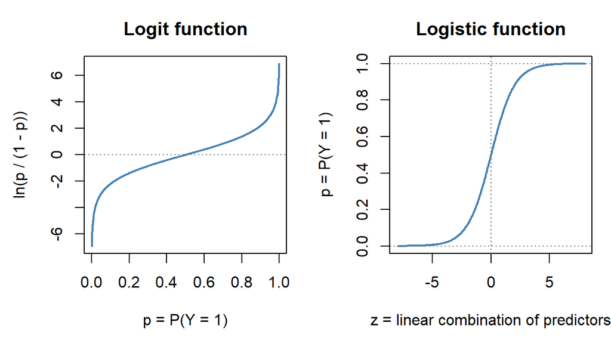

The logit function (left) and the logistic function (right).

The logistic function has several properties that make it well suited to a binary dependent variable:

- **It is bounded between 0 and 1.** No matter how large or small the linear combination of predictors becomes, the result is always a valid probability, which fixes the main problem with OLS.
- **It is S-shaped and monotonic.** The probability always moves in the same direction as the linear combination: a positive coefficient always raises the probability and a negative coefficient always lowers it.
- **It is approximately linear in the middle and flattens at the extremes.** When the probability is near 0.5, a change in a predictor moves the probability substantially, but when the probability is near 0 or 1, the same change moves it very little. This matches how probabilities actually behave, and it means that the effect of a predictor on the *probability* depends on the values of the other predictors, while its effect on the *log odds* is constant.
- **It yields a quantity with a natural interpretation.** The fitted value is the predicted probability that $Y = 1$, and the exponentiated coefficients are odds ratios.

## 2.3 Hypothesis tests for coefficients

For each predictor $k$ in the model, we test the null hypothesis that the predictor is not associated with the odds that a crash involves a drunk driver, holding the other predictors constant, against the alternative that it is:

$$H_0: \beta_k = 0 \qquad H_a: \beta_k
\neq 0$$

The test uses the **Wald statistic**, which divides the estimated coefficient by its standard error:

$$z =
\frac{\hat{\beta}_k}{SE(\hat{\beta}_k)}$$

In large samples, the Wald statistic follows approximately a standard normal distribution under the null hypothesis. Equivalently, its square, $z^2$, follows a chi-square distribution with 1 degree of freedom (some software reports the Wald statistic in this form). We compare the resulting p-value to a significance level of 0.05. If $p < 0.05$ we reject the null hypothesis and conclude that the predictor is significantly associated with the outcome.

Rather than looking at the estimated $\beta$ coefficients, which are changes in the *log* odds and are hard to interpret, most statisticians prefer to look at **odds ratios**, which are calculated by exponentiating the coefficients:

$$OR_k = e^{\hat{\beta}_k}$$

The 95% confidence interval for the odds ratio is obtained by exponentiating the limits of the confidence interval for the coefficient, $e^{\hat{\beta}_k \pm 1.96 \times SE(\hat{\beta}_k)}$. If the confidence interval for an odds ratio excludes 1, the predictor is significant at the 0.05 level, which is equivalent to the Wald test. For a binary predictor, the odds ratio compares crashes with the characteristic to those without it. For a continuous predictor such as MEDHHINC, it is the change in the odds per one-unit increase (here, $1), so it can help to rescale the predictor (for example, to $1,000 units) to make the odds ratio easier to interpret.

## 2.4 Assessing model fit

**R-squared.** A pseudo R-squared can be calculated for logistic regression, but it is no longer considered a very useful metric. It does not have the same interpretation as the R-squared in OLS (the proportion of the variance in the dependent variable explained by the model), and different versions of it give different values. We therefore rely on the measures below.

**Akaike Information Criterion (AIC).** The AIC is a measure used to compare models fit to the same data that balances goodness of fit against model complexity, calculated as $AIC = 2k - 2\ln(\hat{L})$, where $k$ is the number of estimated parameters and $\hat{L}$ is the maximized value of the likelihood function. A **lower AIC indicates a better fit** (a better trade-off between fit and complexity); the AIC has no meaning on its own, only relative to the AIC of another model.

**Fitted values.** Once the model is estimated, the fitted (predicted) value $\hat{y}$ for each crash is calculated by plugging the crash’s predictor values and the estimated coefficients into the logistic form of the model:

$$\hat{y}_i = \hat{p}_i = \frac{1}{1 +
e^{-(\hat{\beta}_0 + \hat{\beta}_1 x_{1i} + \dots + \hat{\beta}_9
x_{9i})}}$$

Unlike in OLS, $\hat{y}$ is not a prediction of the outcome itself (which can only be 0 or 1). It is the **predicted probability that $Y = 1$**, that is, the predicted probability that the crash involved a drunk driver, and it always lies between 0 and 1.

**Sensitivity, specificity and misclassification rate.** To judge how well the model classifies crashes, we choose a **cut-off** value $c$ and classify a crash as $\hat{Y} = 1$ if $\hat{y} > c$ and as $\hat{Y} = 0$ otherwise. Comparing the predicted classes with the actual outcomes gives four counts: true positives (TP), false positives (FP), true negatives (TN) and false negatives (FN). From these we calculate:

- **Sensitivity** (true positive rate) $= \dfrac{TP}{TP + FN}$: the proportion of crashes that actually involved a drunk driver that the model correctly classifies as such. *Higher values are better.*
- **Specificity** (true negative rate) $= \dfrac{TN}{TN + FP}$: the proportion of crashes that did not involve a drunk driver that the model correctly classifies as such. *Higher values are better.*
- **Misclassification rate** $= \dfrac{FP + FN}{TP + FP + TN + FN}$: the proportion of all crashes that the model classifies incorrectly. *Lower values are better.*

**Why try different cut-offs.** The conventional cut-off of 0.5 is not appropriate when the outcome is rare. Only about 6% of crashes in our data involve a drunk driver, so very few crashes will have a predicted probability above 0.5, and the model will classify nearly every crash as “no alcohol.” This produces high specificity and a low misclassification rate, but sensitivity close to zero, so the model would be of little use for identifying drunk-driving crashes. Sensitivity and specificity also trade off against each other: lowering the cut-off raises sensitivity but lowers specificity, and raising it does the opposite. We therefore calculate all three measures over a range of cut-offs to see how the trade-off changes.

**ROC curve.** The Receiver Operating Characteristic (ROC) curve summarizes this trade-off across *all* possible cut-offs. It plots sensitivity (the true positive rate) on the vertical axis against 1 − specificity (the false positive rate) on the horizontal axis. A model with no predictive ability falls along the 45-degree diagonal, while a better model bows toward the upper-left corner, where sensitivity and specificity are both 1. The ROC curve can be used to choose an optimal cut-off in two common ways:

1. **Closest to the upper-left corner:** choose the cut-off whose point on the curve has the smallest distance to the point (0, 1), that is, the cut-off that minimizes $\sqrt{(1 - \text{sensitivity})^2 + (1 - \text{specificity})^2}$.
2. **Youden’s index:** choose the cut-off that maximizes $\text{sensitivity} + \text{specificity} - 1$, the point farthest above the diagonal.

Both methods give equal weight to sensitivity and specificity, so unlike the misclassification rate they are not dominated by the much larger group of crashes without alcohol. In this report we use the **closest-to-upper-left-corner** method.

**Area under the curve (AUC).** The area under the ROC curve summarizes the model’s ability to discriminate between the two outcomes in a single number between 0.5 and 1. It can be interpreted as the probability that a randomly chosen crash involving a drunk driver has a higher predicted probability than a randomly chosen crash that did not. An AUC of 0.5 means the model is no better than chance, and an AUC of 1 means perfect discrimination. Commonly used benchmarks are:

| AUC | Model quality |
| --- | --- |
| 0.9 – 1.0 | Excellent |
| 0.8 – 0.9 | Good |
| 0.7 – 0.8 | Fair |
| 0.6 – 0.7 | Poor |
| 0.5 – 0.6 | Failing |

## 2.5 Assumptions

Logistic regression requires that the dependent variable be binary and that the sample be large enough (we use a rule of thumb of at least 50 observations per predictor). It shares some, but not all, of the other assumptions of OLS regression.

**OLS assumptions that also hold for logistic regression:**

- **Independence of observations.** The observations should not be related to one another.
- **No severe multicollinearity.** The predictors should not be highly correlated with each other.
- **No highly influential outliers.** A small number of unusual observations should not drive the results.
- **Correct model specification.** The model should include the relevant predictors and exclude irrelevant ones.

**OLS assumptions that do *not* hold for logistic regression:**

- **A linear relationship between the predictors and the dependent variable.** Logistic regression only requires a linear relationship between the predictors and the *logit* (log odds) of the outcome; the relationship with the probability itself is S-shaped.
- **Normally distributed residuals.** The errors of a binary outcome cannot be normal.
- **Homoscedasticity (constant error variance).** The variance of a binary outcome depends on its mean, so it is not constant by construction.

## 2.6 Exploratory analyses

Before running a logistic regression, statisticians typically explore the relationship between the dependent variable and each predictor.

**Binary predictors.** We cross-tabulate the dependent variable with each binary predictor to see whether the two variables are associated. The appropriate statistical test for examining the association between two categorical variables is the **Chi-Square test of independence** (described in the course notes), which compares the observed cell counts in the cross-tabulation with the counts that would be expected if the two variables were unrelated. The hypotheses are:

- $H_0$: The two variables are independent; there is no association between the predictor and DRINKING_D (the proportion of crashes with the characteristic is the same for crashes with and without a drunk driver).
- $H_a$: The two variables are not independent; there is an association between the predictor and DRINKING_D (the proportions differ).

The test statistic is $\chi^2 = \sum \frac{(O - E)^2}{E}$, where $O$ and $E$ are the observed and expected counts in each cell, with $(r - 1)(c - 1) = 1$ degree of freedom for a 2 × 2 table. We reject $H_0$ when $p < 0.05$. The test is reliable when all expected counts are at least 5. The cross-tabulations also reveal sparse or empty cells, which can cause estimation problems such as separation in logistic regression.

**Continuous predictors.** We can also compare the means of the continuous predictors for each value of the dependent variable. The appropriate tests for examining whether the mean values of PCTBACHMOR and MEDHHINC differ between crashes that involved alcohol and those that did not are **independent samples t-tests** (described in the course notes). For each variable, the hypotheses are:

- $H_0$: $\mu_{\text{alcohol}} = \mu_{\text{no alcohol}}$; the mean of the variable is the same for crashes with and without alcohol involvement.
- $H_a$: $\mu_{\text{alcohol}} \neq \mu_{\text{no alcohol}}$; the mean differs between the two groups.

# 3 Results

## 3.1 Exploratory analyses

### 3.1.1 Dependent variable

The tabulation of the dependent variable below shows that of crashes in the sample (43,364), 40,879 or 94.27% were reported as no alcohol involved while 2,485 or 5.73% were reported as alcohol involved. Because the percentage of alcohol involved crashes fall between 5% and 10%, they are characterized as relatively rare. We want at least 50 observations per predictor to ensure a large enough sample to run a logistic regression. With 43,364 total crashes, we meet that requirement.

Tabulation of DRINKING_D

| DRINKING_D | N | Proportion |
| --- | --- | --- |
| 0 (No alcohol involved) | 40879 | 0.9427 |
| 1 (Alcohol involved) | 2485 | 0.0573 |

### 3.1.2 Cross-tabulations and Chi-Square tests

For six of the seven binary predictors, the p-value is < .001, so we reject the null hypothesis of no association between each of these predictors and the dependent variable. The cross-tabulation of the dependent variable with each binary predictor demonstrates that crashes involving a drunk driver were considerably more likely to result in a fatality or major injury (7.57% drunk vs. 2.89% not drunk), to involve an overturned vehicle (4.43% drunk vs. 1.50% not drunk), and to involve speeding (10.46% drunk vs. 3.08% not drunk). Speeding shows the strongest association ($\chi^2$ = 376.78), being more than three times as common in alcohol-related crashes. Conversely, aggressive driving (36.86% drunk vs. 45.31% not drunk), drivers aged 16 or 17 (0.48% drunk vs. 1.65% not drunk), and drivers aged 65 or older (4.79% drunk vs. 10.36% not drunk) were all less common in crashes involving a drunk driver. We would like to note that only 12 alcohol-related crashes involved a 16- or 17-year-old driver, so estimates for DRIVER1617 may be imprecise because the sample is so small.

Cross-tabulation of binary predictors with DRINKING_D, with Chi-Square tests (no continuity correction)

| Predictor | No Alcohol (DRINKING_D = 0) N (No Alcohol) | No Alcohol (DRINKING_D = 0) % (No Alcohol) | Alcohol (DRINKING_D = 1) N (Alcohol) | Alcohol (DRINKING_D = 1) % (Alcohol) | Total N | Chi-Square Test Chi-sq | Chi-Square Test df | Chi-Square Test p-value |
| --- | --- | --- | --- | --- | --- | --- | --- | --- |
| FATAL_OR_M: Crash resulted in fatality or major injury | 1181 | 2.89% | 188 | 7.57% | 1369 | 167.56 | 1 | <0.001 |
| OVERTURNED: Crash involved an overturned vehicle | 612 | 1.50% | 110 | 4.43% | 722 | 122.79 | 1 | <0.001 |
| CELL_PHONE: Driver was using cell phone | 426 | 1.04% | 28 | 1.13% | 454 | 0.16 | 1 | 0.687 |
| SPEEDING: Crash involved speeding car | 1261 | 3.08% | 260 | 10.46% | 1521 | 376.78 | 1 | <0.001 |
| AGGRESSIVE: Crash involved aggressive driving | 18522 | 45.31% | 916 | 36.86% | 19438 | 67.60 | 1 | <0.001 |
| DRIVER1617: Crash involved at least one driver aged 16 or 17 | 674 | 1.65% | 12 | 0.48% | 686 | 20.45 | 1 | <0.001 |
| DRIVER65PLUS: Crash involved at least one driver aged 65+ | 4237 | 10.36% | 119 | 4.79% | 4356 | 80.60 | 1 | <0.001 |

For each binary predictor, the Chi-square test’s null hypothesis is that the dependent variable is independent from each predictor. The alternative is that they are associated. The Chi-Square test shows a significant association between DRINKING_D and every binary predictor except CELL_PHONE (χ² = 0.16, p = 0.687). For CELL_PHONE, p > 0.05, so we fail to reject the null hypothesis.

### 3.1.3 Continuous predictors and t-tests

The mean for PCTBACHMOR in drunk driving crashes is 16.61%, while the mean for crashes not involving alcohol is 16.57%. The mean for MEDHHINC in drunk driving crashes is $31,998.75, while the mean for crashes not involving alcohol is $31,483.05.

Means of continuous predictors by DRINKING_D, with independent samples t-tests

| Predictor | No Alcohol Mean (No Alcohol) | No Alcohol SD (No Alcohol) | Alcohol Mean (Alcohol) | Alcohol SD (Alcohol) | t-test t | t-test df | t-test p-value |
| --- | --- | --- | --- | --- | --- | --- | --- |
| PCTBACHMOR: % with bachelor’s degree or more | 16.57 | 18.21 | 16.61 | 18.72 | -0.11 | 2,777.5 | 0.914 |
| MEDHHINC: Median household income | 31,483.05 | 16,930.10 | 31,998.75 | 17,810.50 | -1.41 | 2,763.9 | 0.160 |

For both PCTBACHMOR (t = -.11, p = .914) and MEDHHINC (t = -1.41, p = .160), p > 0.05, so we fail to reject the null hypothesis that the group means are equal. There is no significant difference in block-group education or income between crashes with and without a drunk driver.

## 3.2 Logistic regression assumptions and multicollinearity

**Assumptions**

- The assumption that the dependent variable is binary is met.
- The assumption that the sample is large enough with at least 50 observations per predictor is met.
- The assumption that observations are independent is possibly violated, since crashes in the same block group share the same PCTBACHMOR and MEDHHINC values.
- The assumption that there is no severe multicollinearity is met.

Pairwise Pearson correlations among predictors

|  | FATAL_OR_M | OVERTURNED | CELL_PHONE | SPEEDING | AGGRESSIVE | DRIVER1617 | DRIVER65PLUS | PCTBACHMOR | MEDHHINC |
| --- | --- | --- | --- | --- | --- | --- | --- | --- | --- |
| FATAL_OR_M | 1.00 | 0.03 | 0.00 | 0.08 | -0.01 | 0.00 | -0.01 | -0.01 | -0.02 |
| OVERTURNED | 0.03 | 1.00 | 0.00 | 0.06 | 0.02 | 0.00 | -0.02 | 0.01 | 0.03 |
| CELL_PHONE | 0.00 | 0.00 | 1.00 | 0.00 | -0.03 | 0.00 | 0.00 | 0.00 | 0.00 |
| SPEEDING | 0.08 | 0.06 | 0.00 | 1.00 | 0.21 | 0.02 | -0.03 | 0.00 | 0.01 |
| AGGRESSIVE | -0.01 | 0.02 | -0.03 | 0.21 | 1.00 | 0.03 | 0.02 | 0.03 | 0.04 |
| DRIVER1617 | 0.00 | 0.00 | 0.00 | 0.02 | 0.03 | 1.00 | -0.02 | 0.00 | 0.02 |
| DRIVER65PLUS | -0.01 | -0.02 | 0.00 | -0.03 | 0.02 | -0.02 | 1.00 | 0.03 | 0.05 |
| PCTBACHMOR | -0.01 | 0.01 | 0.00 | 0.00 | 0.03 | 0.00 | 0.03 | 1.00 | 0.48 |
| MEDHHINC | -0.02 | 0.03 | 0.00 | 0.01 | 0.04 | 0.02 | 0.05 | 0.48 | 1.00 |

**Multicollinearity.** The matrix showing the pairwise Pearson correlations is illustrated above. The Pearson correlation was designed for continuous variables, so it has limitations when applied to binary variables. Two binary variables can only have a correlation of 1 if they have the same proportion of 1s. When one variable is rarer than the other, the maximum possible correlation is less than 1, even if the variables are perfectly related. As a result, Pearson correlations can understate the strength of the association between binary predictors, especially rare ones. We used a |.8| Pearson correlation threshold for determining multicollinearity. No pair of predictors exceeds this threshold, so there is no evidence of severe multicollinearity. The strongest correlations are between PCTBACHMOR and MEDHHINC (r = 0.48) and between SPEEDING and AGGRESSIVE (r = 0.21).

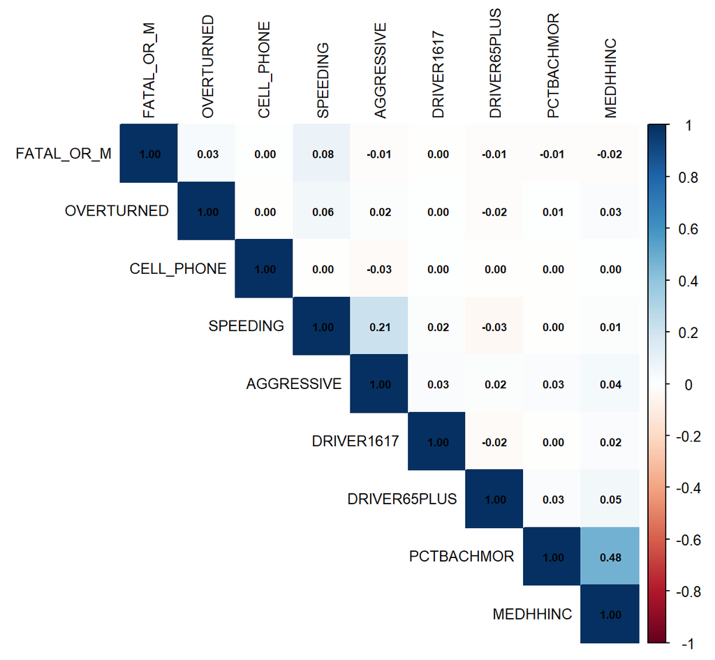

Correlation plot of predictors

## 3.3 Logistic regression: full model

```
##
## Call:
## glm(formula = DRINKING_D ~ FATAL_OR_M + OVERTURNED + CELL_PHONE +
##     SPEEDING + AGGRESSIVE + DRIVER1617 + DRIVER65PLUS + PCTBACHMOR +
##     MEDHHINC, family = binomial(link = "logit"), data = df)
##
## Coefficients:
##                Estimate Std. Error z value Pr(>|z|)
## (Intercept)  -2.733e+00  4.588e-02 -59.563  < 2e-16 ***
## FATAL_OR_M    8.140e-01  8.381e-02   9.713  < 2e-16 ***
## OVERTURNED    9.289e-01  1.092e-01   8.509  < 2e-16 ***
## CELL_PHONE    2.955e-02  1.978e-01   0.149   0.8812
## SPEEDING      1.539e+00  8.055e-02  19.107  < 2e-16 ***
## AGGRESSIVE   -5.969e-01  4.778e-02 -12.493  < 2e-16 ***
## DRIVER1617   -1.280e+00  2.931e-01  -4.367 1.26e-05 ***
## DRIVER65PLUS -7.747e-01  9.586e-02  -8.081 6.41e-16 ***
## PCTBACHMOR   -3.706e-04  1.296e-03  -0.286   0.7750
## MEDHHINC      2.804e-06  1.341e-06   2.091   0.0365 *
## ---
## Signif. codes:  0 '***' 0.001 '**' 0.01 '*' 0.05 '.' 0.1 ' ' 1
##
## (Dispersion parameter for binomial family taken to be 1)
##
##     Null deviance: 19036  on 43363  degrees of freedom
## Residual deviance: 18340  on 43354  degrees of freedom
## AIC: 18360
##
## Number of Fisher Scoring iterations: 6
```

Logistic regression results: full model (odds ratios and 95% CIs)

|  | Coefficient | Std. Error | z value | p-value | Odds Ratio | CI 2.5% | CI 97.5% |
| --- | --- | --- | --- | --- | --- | --- | --- |
| (Intercept) | -2.7325 | 0.0459 | -59.5633 | 0.0000 | 0.0651 | 0.0595 | 0.0712 |
| FATAL_OR_M | 0.8140 | 0.0838 | 9.7130 | 0.0000 | 2.2569 | 1.9099 | 2.6531 |
| OVERTURNED | 0.9289 | 0.1092 | 8.5092 | 0.0000 | 2.5318 | 2.0346 | 3.1224 |
| CELL_PHONE | 0.0296 | 0.1978 | 0.1494 | 0.8812 | 1.0300 | 0.6835 | 1.4885 |
| SPEEDING | 1.5390 | 0.0805 | 19.1068 | 0.0000 | 4.6598 | 3.9741 | 5.4502 |
| AGGRESSIVE | -0.5969 | 0.0478 | -12.4932 | 0.0000 | 0.5505 | 0.5010 | 0.6042 |
| DRIVER1617 | -1.2803 | 0.2931 | -4.3674 | 0.0000 | 0.2780 | 0.1477 | 0.4711 |
| DRIVER65PLUS | -0.7747 | 0.0959 | -8.0814 | 0.0000 | 0.4609 | 0.3800 | 0.5535 |
| PCTBACHMOR | -0.0004 | 0.0013 | -0.2859 | 0.7750 | 0.9996 | 0.9971 | 1.0022 |
| MEDHHINC | 0.0000 | 0.0000 | 2.0914 | 0.0365 | 1.0000 | 1.0000 | 1.0000 |

Seven of the nine predictors are statistically significant at the 0.05 level; CELL_PHONE (*p* = 0.881) and PCTBACHMOR (*p* = 0.775) are not. Holding all other predictors constant:

- **FATAL_OR_M:** Crashes resulting in a fatality or major injury have **2.26 times** the odds of involving a drunk driver (126% higher odds) compared to crashes without a fatality or major injury.
- **OVERTURNED:** Crashes involving an overturned vehicle have **2.53 times** the odds of involving a drunk driver (153% higher odds).
- **CELL_PHONE:** *Not significant.* The odds ratio of 1.03 is close to 1 and its 95% confidence interval (0.68–1.49) includes 1, so there is no evidence that cell phone use is associated with drunk driving.
- **SPEEDING:** Crashes involving speeding have **4.66 times** the odds of involving a drunk driver (366% higher odds). This is the strongest predictor in the model.
- **AGGRESSIVE:** Crashes involving aggressive driving have **0.55 times** the odds of involving a drunk driver (45% lower odds).
- **DRIVER1617:** Crashes involving a 16- or 17-year-old driver have **0.28 times** the odds of involving a drunk driver (72% lower odds).
- **DRIVER65PLUS:** Crashes involving a driver aged 65 or older have **0.46 times** the odds of involving a drunk driver (54% lower odds).
- **PCTBACHMOR:** *Not significant.* Each one-percentage-point increase in the share of residents with a bachelor’s degree is associated with essentially no change in the odds (OR = 0.9996; 95% CI includes 1).
- **MEDHHINC:** *Significant* (*p* = 0.037). Higher block-group median household income is associated with slightly higher odds of a crash involving a drunk driver. Because income is measured in dollars, the odds ratio per $1 is very close to 1; each $1,000 increase in median household income is associated with about a 0.3% increase in the odds.

Notably, MEDHHINC was not significant in the t-test but is significant in the regression, suggesting that its association with drunk driving only appears after controlling for the other crash characteristics.

## 3.4 Classification: sensitivity, specificity and misclassification

The table below presents the sensitivity, specificity, and misclassification rate of the full model at each probability cut-off. A crash is classified as involving a drunk driver when its predicted probability is above the cut-off. Sensitivity is the proportion of drunk-driving crashes correctly classified, specificity is the proportion of non-drunk-driving crashes correctly classified, and the misclassification rate is the proportion of all crashes classified incorrectly. The table shows the tradeoff between sensitivity and specificity because as one goes up, the other goes down and vice versa. At low cut-offs, almost every crash is classified as involving a drunk driver: at a cut-off of 0.02, sensitivity is 0.98 but specificity is only 0.06. As the cut-off increases, fewer crashes are classified as involving a drunk driver, so specificity rises and sensitivity falls. At a cut-off of 0.50, specificity is nearly perfect (0.9999), but sensitivity is close to zero (0.0016), meaning the model identifies almost none of the drunk-driving crashes. The largest change occurs between cut-offs of 0.05 and 0.07, where sensitivity drops from 0.73 to 0.22 and specificity rises from 0.47 to 0.91.

Sensitivity, specificity and misclassification rate by cut-off (lowest misclassification rate highlighted)

| Cut-off Value | Sensitivity | Specificity | Misclassification Rate |
| --- | --- | --- | --- |
| 0.02 | 0.9835 | 0.0581 | 0.8889 |
| 0.03 | 0.9807 | 0.0639 | 0.8835 |
| 0.05 | 0.7348 | 0.4691 | 0.5157 |
| 0.07 | 0.2213 | 0.9138 | 0.1259 |
| 0.08 | 0.1847 | 0.9386 | 0.1046 |
| 0.09 | 0.1682 | 0.9460 | 0.0986 |
| 0.10 | 0.1642 | 0.9482 | 0.0967 |
| 0.15 | 0.1042 | 0.9722 | 0.0775 |
| 0.20 | 0.0229 | 0.9954 | 0.0603 |
| 0.50 | 0.0016 | 0.9999 | 0.0573 |

The highest misclassification rate (.8889) occurs at a threshold of .02, and the lowest (.0573) occurs at a threshold of .5. The misclassification rate at .5, however, is misleading because only 5.73% of crashes involve a drunk driver, so a model that characterizes all crashes as not involving alcohol will be wrong 5.73% of the time, which is about the rate of misclassification at this cut off. The misclassification rate counts every incorrect classification equally, so it is dominated by the much larger group of non-alcohol crashes. The ROC method instead gives equal weight to sensitivity and specificity, so it selects a much lower cut-off that identifies far more drunk-driving crashes, at the cost of more false positives. Because the goal is to identify drunk-driving crashes, the ROC-based cut-off is more useful.

## 3.5 ROC curve and AUC

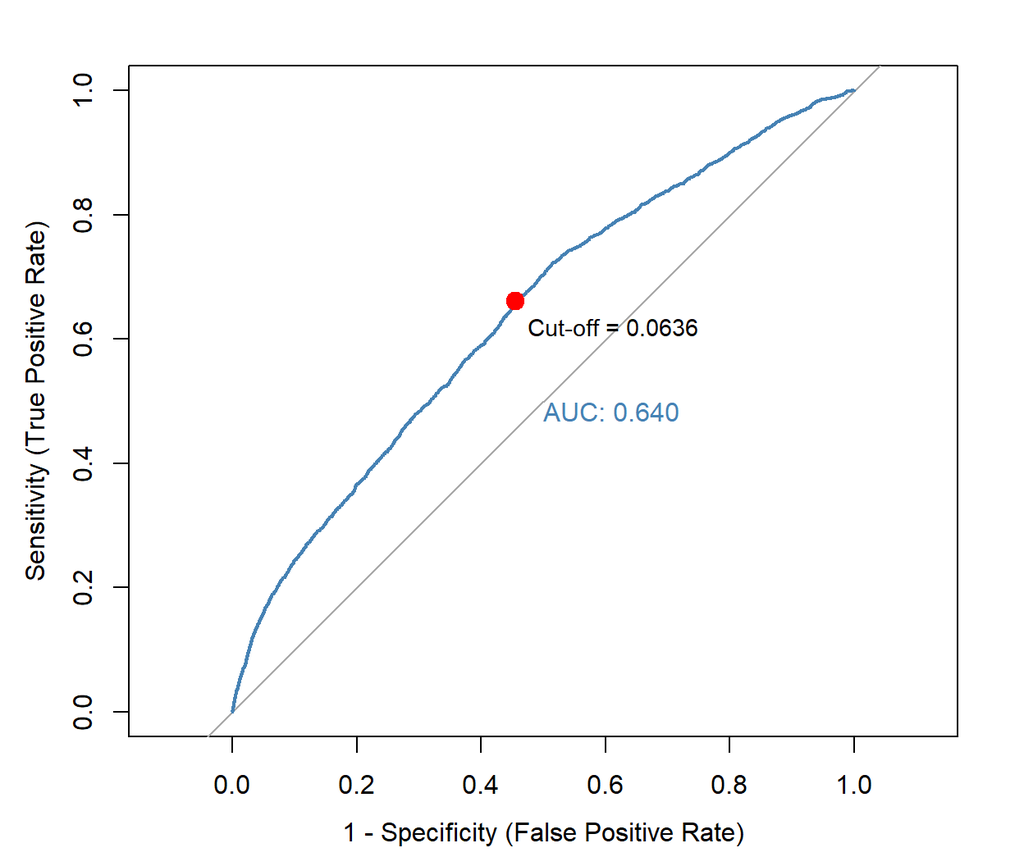

ROC curve for the full model; the red point marks the cut-off closest to the upper left corner

The optimal cut-off was selected as the point on the ROC curve with the minimum distance from the upper left corner (0, 1), where sensitivity and specificity both equal 1. This distance is $\sqrt{(1-\text{sensitivity})^2 + (1-\text{specificity})^2}$, and it was computed using the closest.topleft method in the pROC package. The optimal cut-off is .0636, with sensitivity of 0.6608 and specificity of 0.5452.

The optimal cut-off selected by minimizing the distance from the upper-left corner of the ROC curve is very different from the cut-off selected by minimizing misclassification error.

Comparison of optimal cut-offs

| Criterion | Cut-off Value | Sensitivity | Specificity | Misclassification Rate |
| --- | --- | --- | --- | --- |
| Minimum misclassification rate | 0.5000 | 0.0016 | 0.9999 | 0.0573 |
| Closest to upper left corner of ROC curve | 0.0636 | 0.6608 | 0.5452 | 0.4481 |

The ROC-optimal cut-off (0.0636) correctly identifies 66% of drunk-driving crashes, compared with less than 1% at the 0.50 cut-off. This comes at the cost of a much higher misclassification rate (0.45 vs. 0.06), because many more non-drunk-driving crashes are incorrectly flagged.

The Area Under the Curve (AUC) can be interpreted as the probability that a randomly selected crash involving a drunk driver has a higher predicted probability than a randomly selected crash that did not. An AUC of 0.5 means the model is no better than chance, and 1.0 means perfect discrimination. Based on the benchmarks in the Methods section, an AUC of .6399 indicates poor or weak predictive accuracy. In other words, there is about a 64% chance that the model assigns a higher predicted probability to a randomly selected drunk-driving crash than to a randomly selected crash without a drunk driver. This suggests that the predictors in our model, while statistically significant, do a weak job of distinguishing between crashes with and without drunk drivers, possibly because other critical factors are not included in the model.

## 3.6 Logistic regression: binary predictors only

The table below presents the results of the logistic regression with only the seven binary predictors, excluding PCTBACHMOR and MEDHHINC.

Logistic regression results: binary predictors only (odds ratios and 95% CIs)

|  | Coefficient | Std. Error | z value | p-value | Odds Ratio | CI 2.5% | CI 97.5% |
| --- | --- | --- | --- | --- | --- | --- | --- |
| (Intercept) | -2.6519 | 0.0275 | -96.3239 | 0.0000 | 0.0705 | 0.0668 | 0.0744 |
| FATAL_OR_M | 0.8093 | 0.0838 | 9.6621 | 0.0000 | 2.2464 | 1.9011 | 2.6405 |
| OVERTURNED | 0.9398 | 0.1090 | 8.6192 | 0.0000 | 2.5594 | 2.0574 | 3.1557 |
| CELL_PHONE | 0.0311 | 0.1978 | 0.1571 | 0.8752 | 1.0316 | 0.6846 | 1.4907 |
| SPEEDING | 1.5403 | 0.0805 | 19.1278 | 0.0000 | 4.6661 | 3.9796 | 5.4573 |
| AGGRESSIVE | -0.5936 | 0.0477 | -12.4330 | 0.0000 | 0.5523 | 0.5027 | 0.6062 |
| DRIVER1617 | -1.2716 | 0.2931 | -4.3382 | 0.0000 | 0.2804 | 0.1490 | 0.4752 |
| DRIVER65PLUS | -0.7665 | 0.0958 | -8.0036 | 0.0000 | 0.4647 | 0.3832 | 0.5579 |

The results are very similar to those of the full model. The same six binary predictors remain statistically significant (p < 0.001): FATAL_OR_M, OVERTURNED, SPEEDING, AGGRESSIVE, DRIVER1617 and DRIVER65PLUS. CELL_PHONE remains not significant (p = .8752). The direction and approximate value of each odds ratio are also nearly unchanged. For example, crashes involving speeding have 4.6661 times the odds of involving a drunk driver, compared with 4.6598 in the full model. No predictor that was significant in the full model becomes non-significant in the reduced model, and no predictor that was non-significant becomes significant.

AIC comparison

|  | df | AIC |
| --- | --- | --- |
| Full model (with PCTBACHMOR, MEDHHINC) | 10 | 18359.6 |
| Binary predictors only | 8 | 18360.5 |

The full model has an AIC of 18359.6 vs the binary predictor-only model, which has an AIC of 18360.5. Because a lower AIC indicates a better balance between model fit and complexity, the full model is technically the better model. However, the difference (0.9) is very small. Differences of less than 2 are generally considered negligible, so the two models perform about equally well. This is consistent with the full model results, where MEDHHINC is the only one of the two dropped variables that is significant (p = 0.037), and it adds little to the model’s explanatory power.

# 4 Discussion

In this report, we used logistic regression to examine which crash and neighborhood characteristics are associated with drunk driving among the 43,364 crashes that occurred in Philadelphia’s residential block groups between 2008 and 2012. Speeding was the strongest predictor: crashes involving a speeding car had 4.66 times the odds of involving a drunk driver, holding the other predictors constant. Crashes involving an overturned vehicle (OR = 2.53) or resulting in a fatality or major injury (OR = 2.26) were also more likely to involve alcohol, while crashes involving aggressive driving (OR = 0.55), a driver aged 65 or older (OR = 0.46) or a 16- or 17-year-old driver (OR = 0.28) were less likely to. Cell phone use and the percent of block-group residents with a bachelor’s degree were not associated with drunk driving, and median household income, although significant, had a very small effect (about a 0.3% increase in the odds per $1,000). Most of these results are in the direction we expected. Speeding and crash severity are positively associated with drunk driving, the youngest and oldest drivers are less likely to be involved, and cell phone use, which we saw as a separate form of distraction, is unrelated. The surprising result is aggressive driving, which we expected to be more common in drunk-driving crashes but which instead lowers the odds by 45%, both in the cross-tabulation and in the regression. One possible explanation is that aggressive driving, such as tailgating or running red lights, is common in congested daytime traffic, while drunk-driving crashes tend to happen at night. It is also possible that when a driver is impaired, police record alcohol rather than aggressive driving as the main factor in the crash.

Only 2,485 crashes (5.73%) involved a drunk driver, so the outcome is relatively rare. However, Paul Allison argues that the problem with rare events is not a low percentage of events but a small number of events in absolute terms, which can bias maximum likelihood estimates. With 2,485 events, or about 276 per predictor, our sample is large enough for standard logistic regression, and rare-events methods such as Firth’s penalized likelihood are unlikely to change our results. The one exception is DRIVER1617, since only 12 alcohol-related crashes involved a 16- or 17-year-old driver, so its estimate should be read with caution. The analysis also has several other limitations. The AUC of 0.64 shows that the model distinguishes poorly between crashes with and without a drunk driver, likely because it leaves out factors that are strongly tied to drinking, such as time of day, day of week and proximity to bars. The neighborhood predictors come from the 2000 Census, several years before the crashes took place, and they describe the block group where the crash happened rather than where the driver lives or was drinking. Because crashes in the same block group share the same PCTBACHMOR and MEDHHINC values, the observations are not fully independent, and spatial autocorrelation is not accounted for. Alcohol involvement is reported by police and is likely under-reported, and excluding the 9,896 crashes in non-residential block groups may leave out commercial areas where nightlife, and drunk driving, are concentrated. Finally, FATAL_OR_M and OVERTURNED describe the outcome of a crash rather than its cause, and because the data are cross-sectional, all of the relationships reported here are associations, not causal effects.